# IE360 HW2

Göksel Bilici

16.12.2020

# INTRODUCTION

When we think about [welfare](https://en.wikipedia.org/wiki/Welfare) and [cost of living](https://en.wikipedia.org/wiki/Cost_of_living) type of things, maybe one of the most important factor to look at is the CPI, consumer price index. Because it is calculated by taking price changes for each item in the predetermined [basket of goods](https://www.investopedia.com/terms/b/basket_of_goods.asp) and averaging them.

In Turkey, especially in the last years, the price of food, electronic and many more things almost always increased. And that can be explained by a lot of variable, like overall production, country policies, foreign relationship, the trust Turkey gives to investors and traders etc. But when we think about it like there is a connection between price increases and USA Dollar exchange rates over Turkish Lira’s. Whenever there is a high increase in the exchange rate, one or two months later we feel there is a price increase in the products we consume. That is seen especially in electronic and technological products and probably one of the reasons for that is because these products come from abroad and international traders use USD in exchange of their products.

When an imports take place , consumers either have the ability to choose between domestic products and nondomestic ones or they have to buy the nondomestic ones to satisfy their needs.When a country’s traders use more and more of their money to buy product outside the country meaning when their is an increasing amount of imports in the country’s market, comsumers tend to or have to buy more nondomestic products. Therefore, country’s own amount of money in the global market increase which may result in higher [inflation](https://www.investopedia.com/terms/i/inflation.asp), which may cause the price of products to increase. Therefore, it is expected that the more a country use it own money to import goods the more CPI.

# DATA MANIPULATION and VISUALIZATION

## The Data

```r
library("xlsx")
library("ggplot2")
library("lubridate")
library("corrgram")
library("GGally")
library("dplyr")
```

```r
# import data
theData <- read.xlsx("D:/AILEvs/EZ/EGITIM/AAAA_EE_4.YIL/IE_360/HW2/CPI_Dollar_Import_Data.xls", sheetIndex=1)
# making sure to get data without error
theData <- theData[1:154,1:4]
```

```r
# Calculate imports in terms of TL
theData <- theData %>%
  mutate(Imports = Imports *Dollar)
```

```r
# our data structure
str(theData)
```

```
## 'data.frame':    154 obs. of  4 variables:
##  $ Date   : Date, format: "2008-01-15" "2008-02-15" ...
##  $ CPI    : num  147 149 150 153 155 ...
##  $ Dollar : num  1.17 1.19 1.23 1.3 1.25 ...
##  $ Imports: num  18512 18035 20120 22136 23195 ...
```

```r
head(theData)
```

```
##         Date    CPI   Dollar  Imports
## 1 2008-01-15 146.94 1.170436 18511.62
## 2 2008-02-15 148.84 1.188171 18035.25
## 3 2008-03-15 150.27 1.232376 20119.77
## 4 2008-04-15 152.79 1.296714 22136.21
## 5 2008-05-15 155.07 1.246995 23195.36
## 6 2008-06-15 154.51 1.227800 23016.34
```

Before dive into detail of relation analysis of our data, let’s look at them separately and analyze how they change throughout time.

### CPI

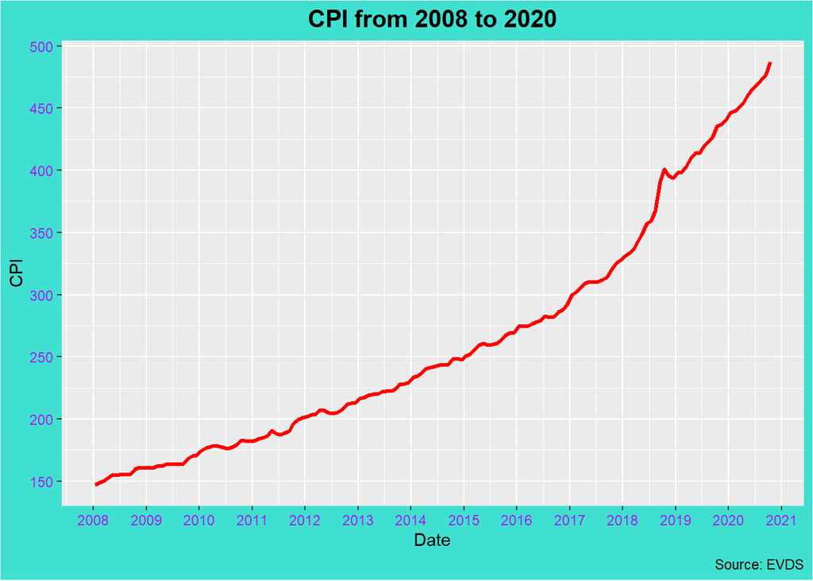

```r
ggplot(theData, aes(Date , CPI))+
  geom_line(color = "red", size = 1.2)+
  scale_y_continuous(breaks = seq(100, 500, by = 50))+
  scale_x_date(date_breaks = "1 year", date_labels =  "%Y")+
  labs(title = "CPI from 2008 to 2020",
       caption = "Source: EVDS")+
  theme(rect = element_rect(fill = "turquoise"),
        plot.title = element_text(color = "black", size = 15, face = "bold", hjust = 0.5),
        axis.text  =element_text(color = "purple")
  )
```

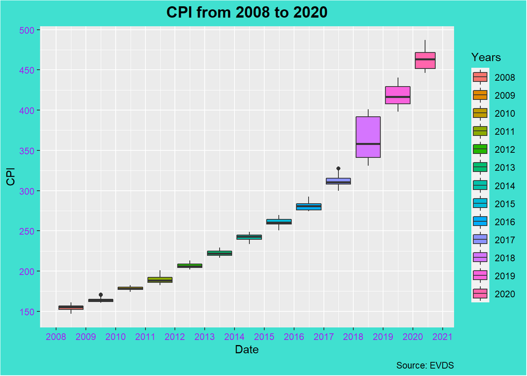

```r
ggplot(theData, aes(Date , CPI))+
  geom_boxplot(aes(fill= factor(year(Date))))+
  scale_y_continuous(breaks = seq(150, 500, by = 50))+
  labs(title = "CPI from 2008 to 2020",
       caption = "Source: EVDS",
       fill = "Years")+
  scale_x_date(date_breaks = "1 year", date_labels =  "%Y")+
  theme(rect = element_rect(fill = "turquoise"),
        plot.title = element_text(color = "black", size = 15, face = "bold", hjust = 0.5),
        axis.text  =element_text(color = "purple")
  )
```

### USD Exchange Rates

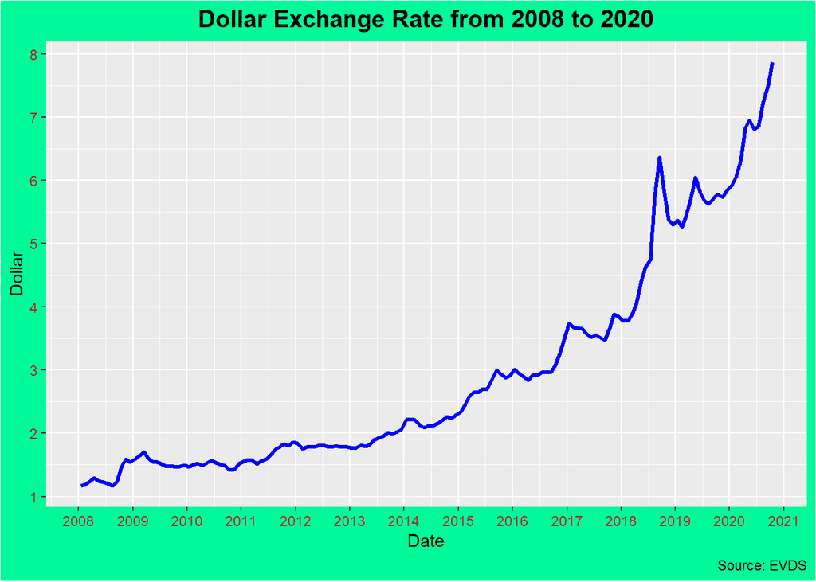

```r
ggplot(theData, aes(Date , Dollar))+
  geom_line(color = "blue", size = 1.2)+
  scale_y_continuous(breaks = seq(1, 10, by = 1))+
  scale_x_date(date_breaks = "1 year", date_labels =  "%Y")+
  labs(title = "Dollar Exchange Rate from 2008 to 2020",
       caption = "Source: EVDS")+
  theme(rect = element_rect(fill = "#00FA9A"),
        plot.title = element_text(color = "black", size = 15, face = "bold", hjust = 0.5),
        axis.text  =element_text(color = "brown")
  )
```

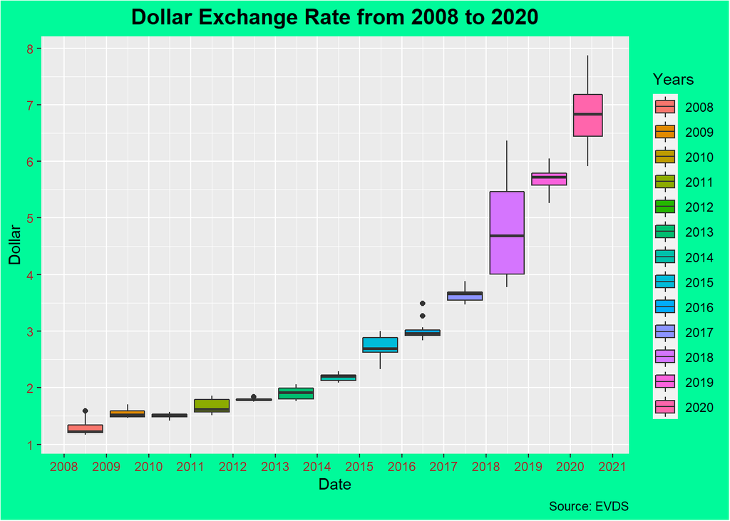

```r
ggplot(theData, aes(Date , Dollar))+
  geom_boxplot(aes(fill= factor(year(Date))))+
  scale_y_continuous(breaks = seq(1, 10, by = 1))+
  labs(title = "Dollar Exchange Rate from 2008 to 2020",
       caption = "Source: EVDS",
       fill = "Years")+
  scale_x_date(date_breaks = "1 year", date_labels =  "%Y")+
  theme(rect = element_rect(fill = "#00FA9A"),
        plot.title = element_text(color = "black", size = 15, face = "bold", hjust = 0.5),
        axis.text  =element_text(color = "brown")
  )
```

### Imports

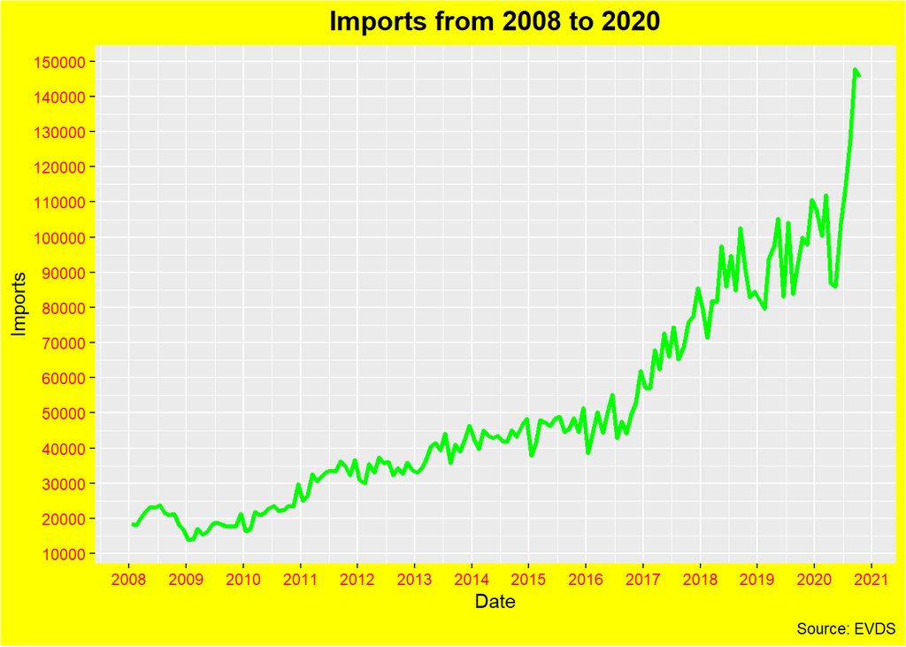

```r
ggplot(theData, aes(Date , Imports))+
  geom_line(color = "green", size = 1.2)+
  scale_y_continuous(breaks = seq(10000, 150000, by = 10000))+
  scale_x_date(date_breaks = "1 year", date_labels =  "%Y")+
  labs(title = "Imports from 2008 to 2020",
       caption = "Source: EVDS")+
  theme(rect = element_rect(fill = "yellow"),
        plot.title = element_text(color = "black", size = 15, face = "bold", hjust = 0.5),
        axis.text  =element_text(color = "red")
  )
```

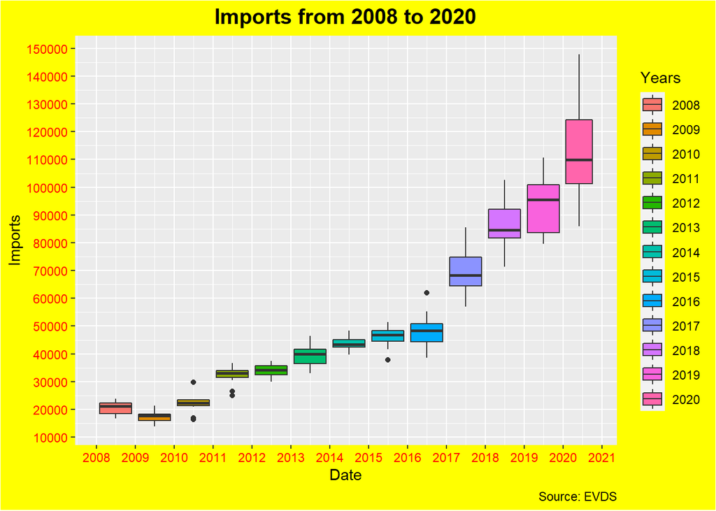

```r
ggplot(theData, aes(Date , Imports))+
  geom_boxplot(aes(fill= factor(year(Date))))+
  scale_y_continuous(breaks = seq(10000, 150000, by = 10000))+
  labs(title = "Imports from 2008 to 2020",
       caption = "Source: EVDS",
       fill = "Years")+
  scale_x_date(date_breaks = "1 year", date_labels =  "%Y")+
  theme(rect = element_rect(fill = "yellow"),
        plot.title = element_text(color = "black", size = 15, face = "bold", hjust = 0.5),
        axis.text  =element_text(color = "red")
  )
```

## Correlation Analysis

```r
theCorrelation <- cor(theData[,2:4])
theCorrelation
```

```
##               CPI    Dollar   Imports
## CPI     1.0000000 0.9837203 0.9690986
## Dollar  0.9837203 1.0000000 0.9609419
## Imports 0.9690986 0.9609419 1.0000000
```

[figure not shown]

```r
corrgram(theCorrelation, order=FALSE, lower.panel=panel.shade,
         upper.panel=panel.pie, text.panel=panel.txt,
         main="Correlation of CPI, Dollar and Imports Data ")
```

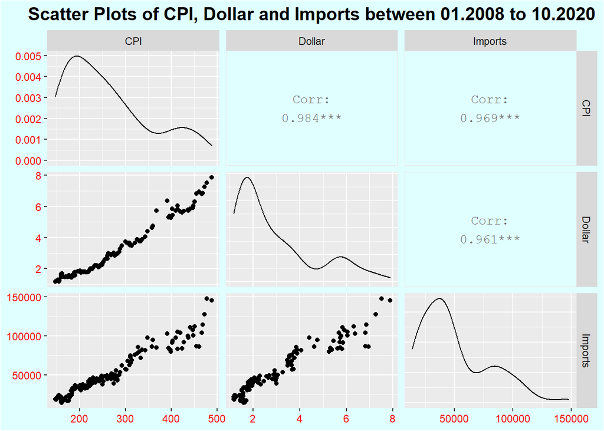

```r
ggpairs(theData[,2:4]) +
  labs(title ="Scatter Plots of CPI, Dollar and Imports between 01.2008 to 10.2020")+
  theme(rect = element_rect(fill = "#E0FFFF"),
        plot.title = element_text(color = "black", size = 15, face = "bold", hjust = 0.5),
        axis.text  =element_text(color = "red")
  )
```

### CPI and Exchange Rates Relations

```r
cor.test(theData$CPI, theData$Dollar)
```

```
##
##  Pearson's product-moment correlation
##
## data:  theData$CPI and theData$Dollar
## t = 67.489, df = 152, p-value < 2.2e-16
## alternative hypothesis: true correlation is not equal to 0
## 95 percent confidence interval:
##  0.9776715 0.9881403
## sample estimates:
##       cor
## 0.9837203
```

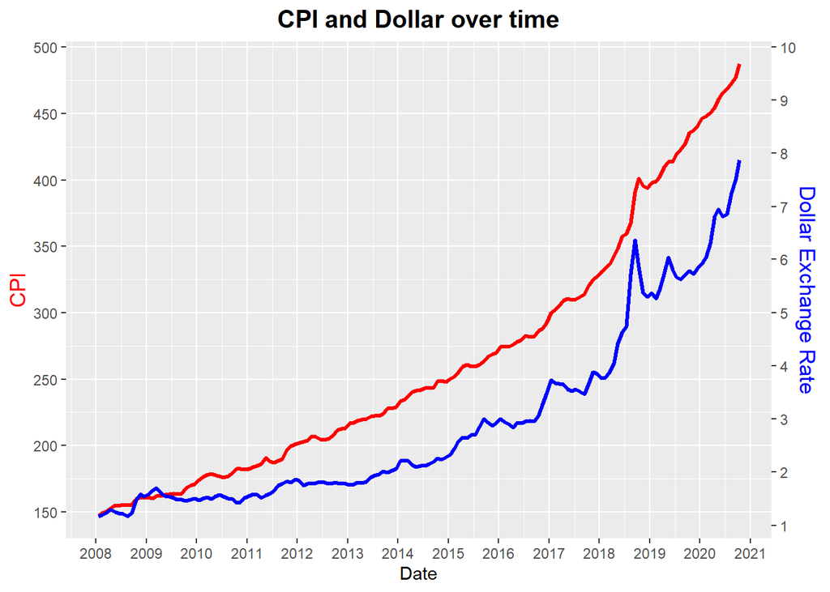

```r
ggplot(theData, aes(Date))+
  geom_line(aes(y = CPI),color = "red", size = 1.2)+
  geom_line(aes(y = Dollar*40 + 100),color = "blue", size = 1.2)+
  scale_x_date(date_breaks = "1 year", date_labels =  "%Y")+
  scale_y_continuous(breaks = seq(100, 500, by = 50),
                     sec.axis = sec_axis(trans=~./40 - 2.5, name = "Dollar Exchange Rate",breaks = seq(1, 10, by = 1)))+
  labs(title = "CPI and Dollar over time")+
  theme(axis.title.y = element_text(color = "red", size=13),
        axis.title.y.right = element_text(color = "blue", size=13),
        plot.title = element_text(size = 15, face = "bold", hjust = 0.5)
  )
```

### CPI and Imports Relations

```r
cor.test(theData$CPI, theData$Imports)
```

```
##
##  Pearson's product-moment correlation
##
## data:  theData$CPI and theData$Imports
## t = 48.436, df = 152, p-value < 2.2e-16
## alternative hypothesis: true correlation is not equal to 0
## 95 percent confidence interval:
##  0.9577328 0.9774433
## sample estimates:
##       cor
## 0.9690986
```

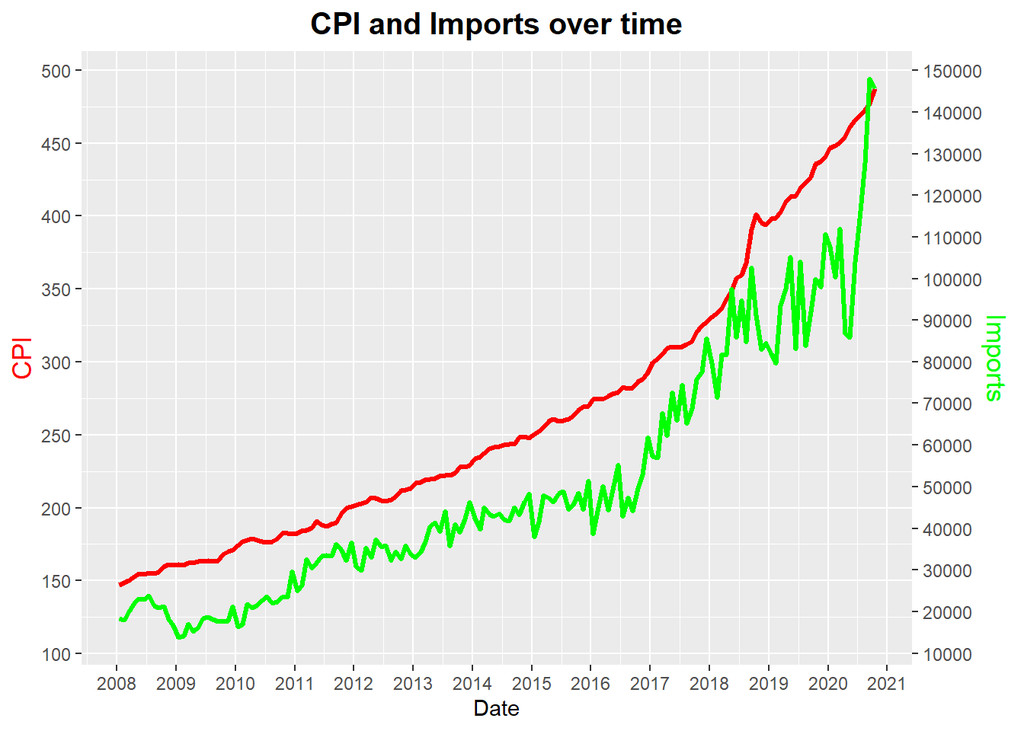

```r
ggplot(theData, aes(Date))+
  geom_line(aes(y = CPI),color = "red", size = 1.2)+
  geom_line(aes(y = Imports/350 + 71.43),color = "green", size = 1.2)+
  scale_x_date(date_breaks = "1 year", date_labels =  "%Y")+
  scale_y_continuous(breaks = seq(100, 500, by = 50),
                     sec.axis = sec_axis(trans=~.*350-25000, name = "Imports",breaks = seq(10000, 150000, by = 10000)))+
  labs(title = "CPI and Imports over time")+
  theme(axis.title.y = element_text(color = "red", size=13),
        axis.title.y.right = element_text(color = "green", size=13),
        plot.title = element_text(size = 15, face = "bold", hjust = 0.5)
  )
```

# REFERENCES

- [Electronic Data Delivery System, Central Bank of Turkey](https://evds2.tcmb.gov.tr/)
- [Wikipedia](https://www.wikipedia.org/)
- [Investopedia](https://www.investopedia.com/)

# Appendices

- Here is the markdown file.